# Power analysis for smallest effect size

Date: 2020-06-19

Author: Thejasvi Beleyur

```python
import numpy as np
np.random.seed(82320)
import matplotlib.pyplot as plt
import pandas as pd
from pandas.core.common import flatten
from shuffle_overlap import shuffle_overlap
from tqdm import tqdm
%matplotlib notebook
```

### What this notebook will do

This notebook will try to estimate the power our kernel-density based overlap method has for a variety of effect sizes. This is *not* a post-hoc power analysis because I am not using the effect-size estimated from the data. There are good reasons not to do post-hoc power-analyses mainly because they do not really reveal the actual power of a test [1,2]. What I will do instead is to run a power analysis to see if the method could pick up the smallest reasonable effects for each parameter of interest.

### Where to get the 'minimum detectable effects' from?

Luckily for us, we also have a previously published study (Fawcett et al. 2015)[3] on another rhinolophid's echolocation behaviour as single individuals and pairs. [3] will be used to set the minimum effect sizes, and calculate the power for these minimum effect sizes.

### Our own effect sizes are likely to be different:

Despite the availability of this published study it is important to note that the effect sizes in our own study may actually be different because of 1) different study species 2) the fact that our study was done in the wild.

Fawcett et al. 2015 studied *Rhinolophus capensis*, which showed changes in their echolocation call behavious when flown with other bats. The fact that the species is different may have consequences on whether we can expect a similar reaction in the bats in our dataset, belonging to *R. euryale* and *R. mehelyi*. For instance, in our field site, the two rhinolophid species regularly fly together inside and outside the cave, forming groups of 2-10 individuals (pers obs.). I don't know if *R. capensis* shows such behaviour. If *R. capensis* is more of a solitary species, then we could expect stronger differences in the echolocation when individuals encounter other individuals.

Fawcett et al.2015 was a lab study, where individual bats and pairs of bats were flown together. It maybe the case that the flight room was a novel context for the bats flown in this study, and thus the changes in their echolocation behavious may reflect an over-amplification of the changes that they show in nature. Our study on the other hand is of bats echolocating in the field. The cave in which the recordings were made is a familiar space frequented by the bats on a daily basis. The familiarity of the cave volume might mean that individual bats may face less of a problem despite the loud calls from conspecifics. The bats in our study may thus show no or very low effect sizes in their echolocation call parameters.

### Calculating 'power' and making the simulated data

The power is the rate at which the statistical test detects true positives. Here 'true positives' are those cases where the comparison of two groups is different by the minimum detectable effect (MDE). I will also implement simulated data where the two groups are from the same distribution to assess the rate of false positives.

For our particular case, the observed percentile of the two distributions is the measure of interest. When the distributions (single and multi bat call parameters) are similar, the overlap percentile will be relatively high (because the observed overlaps are close to the shuffled data overlaps). When the distributions are different, the observed percentiles will be low in comparison to the shuffld data overlaps. Thus the test 'detects' a difference when the observed overlap is *low*.

### How much power is 'enough'?

Since this power analysis is being done *after* the experiments, and not before, the question is how will the resulting power calculations affect our interpretation of the data. We clearly cannot reject any tests which are lower than the typical 0.8 power threshold.

If we do see an effect in our final results, we need to weigh it with the observed power for those parameters. If we do not see differences between our single and multi bat groups, we need to understand how likely it is that the results are a true negative, or a false negative.

How much power is enough really depends on the consequences of the interpretation [4].In our case, it is better to have Type II (false negatives) results rather than Type 1 (false positives), and so even if our power is low - we could still gain a lot by reporting the results as they are. The fact that bats do not adjust their call parameters may actually be a point of discussion.

## Setting the minimum expected effect sizes: what did Fawcett et al. 2015 find?

Luckily for us we have a previous publication with rhinolophid bats [3] which can inform us about the minimum expected effect sizes. Of course, Fawcett et al. 2015 [3] studied the echolocation changes in a different species, (*Rhinolphus capensis*) , and the actual effect sizes may actually be lower in our species. To avoid wild speculation, I'm just going to estimate effect sizes from [3], and then proceed to see what the power of our tests are.

- ### No difference in (CF) peak frequency
- ### 1.25-1.9 X increase in tFM duration in pairs
- ### 0.74 X times shorter calls in pairs
- ### lower minFM in FM sweeps. Drop in minimum frequency (-10dB) between 3-5 kHz
- ### A drop in source level in pairs, but this could also be attributed to changes in beam shape for instance.

```python
def include_measurement_accuracy(X, measurement_accuracy):
    '''
    '''
    return np.array([return_rounded_output(each, measurement_accuracy) for each in X])

def return_rounded_output(each, measurement_accuracy):
    remainder = np.remainder(each, measurement_accuracy)
    if remainder/measurement_accuracy < 0.5:
        return measurement_accuracy*int(each/measurement_accuracy)
    elif remainder/measurement_accuracy >=0.5:
        return measurement_accuracy*(int(each/measurement_accuracy)+1)

dB = lambda X : 20*np.log10(X)
```

```python
# load the raw data across single and multiple bat contexts
df = pd.read_csv('one_call_per_row_2020-07-07.csv')
def calculate_whole_call_duration(one_row):
    regions = ['ifm','cf','tfm']
    durns = [ one_row[each+'_duration']  for each in regions]
    return np.nansum(durns)

df['whole_call_duration'] = df.apply(calculate_whole_call_duration,1)
```

```python
df.columns
```

```
Index(['Unnamed: 0', 'ifm_stop', 'ifm_start', 'ifm_rms', 'ifm_duration',
       'ifm_region_id', 'ifm_terminal_frequency', 'ifm_peak_freq_resolution',
       'ifm_peak_amplitude', 'ifm_peak_frequency', 'cf_stop', 'cf_start',
       'cf_rms', 'cf_duration', 'cf_region_id', 'cf_terminal_frequency',
       'cf_peak_freq_resolution', 'cf_peak_amplitude', 'cf_peak_frequency',
       'tfm_stop', 'tfm_start', 'tfm_rms', 'tfm_duration', 'tfm_region_id',
       'tfm_terminal_frequency', 'tfm_peak_freq_resolution',
       'tfm_peak_amplitude', 'tfm_peak_frequency', 'audio_file',
       'terminal_frequency_threshold', 'video_annot_id', 'num_bats', '0',
       'duration', 'peak_freq_resolution', 'ifm-cf_dbratio', 'tfm-cf_dbratio',
       'ifm-peak_db', 'tfm-peak_db', 'tfm_dbrms', 'ifm_dbrms', 'cf_dbrms',
       'cf-peak_db', 'whole_call_duration'],
      dtype='object')
```

```python
single_bat = df[df['num_bats']==1]
multi_bat = df[df['num_bats']!=1]
```

```python
# let's set our alpha to be 0.05
alpha  = [0.01, 0.05, 0.1]

# the multi and single bat sample sizes based on the actual number of calls from the dataset
single_sample_size = int(single_bat.shape[0])
group_sample_size = int(multi_bat.shape[0])

# number of simulated datasets + trials to run to estimate the power
num_trials = 100
N_shuffles = 500
```

```python
def get_observed_percentiles(Ntrials, group1_data_gen, group2_data_gen, **kwargs):
    '''
    '''
    all_observed_percentiles = []
    for i in tqdm(range(Ntrials)):
        group1_data = group1_data_gen()
        group2_data = group2_data_gen()
        data_overlap, outputs, shuffled_overlaps = shuffle_overlap.overlap_w_shuffling(group1_data,
                                                                                       group2_data, **kwargs)
        observed_percentile = shuffle_overlap.percentile_score_of_value(data_overlap, shuffled_overlaps)
        all_observed_percentiles.append(observed_percentile)
    return all_observed_percentiles


def calculate_power_from_observed_percentiles(obs_percentiles, alpha):
    '''
    Parameters
    ----------
    obs_percentiles : list
        List with observed percentiles, which are floats between 0-100
    alpha : float > 0
        Alpha value or significance criterion.

    Returns
    -------
    power : float >0
    '''
    obs_pc = np.array(obs_percentiles)

    # get all values LEQ the alpha
    leq_alpha  = obs_pc <= alpha
    power  = sum(leq_alpha)/obs_pc.size

    return power



def power_and_true_negative_at_various_alphas(alpha, num_effect_sizes, all_observed_percentiles):
    """
    Parameters
    ----------
    alpha : list/array-like
        The various significance thresholds to be assesed
    num_effect_sizes : int>0
        The number of effects being simulated
    all_observed_percentiles : list
        List with floats containing the percentile run, which is the p-value equivalent.
        The first set of num_trials p-values in the all_observed_percentiles is for the null-hypothesis
        The second set of num_trials p-values in the all_observed_percentiles corresponds to the
        'effect' treatment.
    Returns
    -------
    power_at_alpha : np.array
        Array with the power matrix. Each column corresponds to one effect size, and each row corresponds to one
        significance threshold.

    """
    power_at_alpha = np.zeros((len(alpha), num_effect_sizes))

    obs_pctiles_split = np.array_split(all_observed_percentiles, num_effect_sizes)

    for j, each_pctile in enumerate(obs_pctiles_split):
        for i, sig_threshold in enumerate(alpha):
            true_positive_rate = calculate_power_from_observed_percentiles(each_pctile,
                                                                           sig_threshold)
            power_at_alpha[i, j] = true_positive_rate
    return power_at_alpha
```

```python
def make_overview_plot(df, single, multi, colname):
    mean_colname = np.mean(df[colname])
    sd_colname = np.std(df[colname])
    plt.figure()
    plt.hist(df[colname], alpha=0.5, label=colname)
    plt.hist(single_bat[colname], alpha=0.5, label='single '+colname)
    plt.hist(multi_bat[colname], alpha=0.5, label='multi '+colname)
    plt.vlines(mean_colname, 0, 32)
    plt.text(mean_colname, 33, f'mean: {np.round(mean_colname, 5)}, \n sd: {np.round(sd_colname, 5)}')
    plt.legend()
```

## Simulating the CF peak frequency data

### We will *not* be including separate modelling of Doppler shifts because the analysed CF peak frequencies already result from a variety of emitted CFs and bat flight speeds.

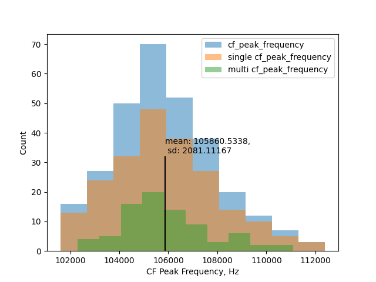

```python
make_overview_plot(df, single_bat, multi_bat, 'cf_peak_frequency')
plt.ylabel('Count');plt.xlabel('CF Peak Frequency, Hz')
```

### Now, lets simulate a case where bats begin to emit *higher* frequencies, by 2 kHz when in groups. Will our tests be able to pick that up?

```python
max_freq_resoln = 600
```

```python
single_cfpeak = shuffle_overlap.generate_kde(single_bat['cf_peak_frequency'])
multi_cfpeak = shuffle_overlap.generate_kde(multi_bat['cf_peak_frequency'])

def cf_generator_single_bat():
    solitary_bat_pf = single_cfpeak.resample(single_sample_size).flatten()
    solitary_bat_pf = include_measurement_accuracy(solitary_bat_pf, max_freq_resoln)
    return solitary_bat_pf

def cf_generator_multi_bat():
    group_bat_pf = multi_cfpeak.resample(group_sample_size).flatten() + shift
    group_bat_pf = include_measurement_accuracy(group_bat_pf, max_freq_resoln)
    return group_bat_pf
```

```python
all_obs_pc = []
cf_shifts = [0, 1000, 2000]
for shift in cf_shifts:
    sim_cf_peak = get_observed_percentiles(num_trials, cf_generator_single_bat, cf_generator_multi_bat,
                                       num_shuffles=N_shuffles)
    all_obs_pc.append(sim_cf_peak)
```

```python
all_obs_pc = list(flatten(all_obs_pc))
power_peakCF = power_and_true_negative_at_various_alphas(alpha, 3, all_obs_pc)
```

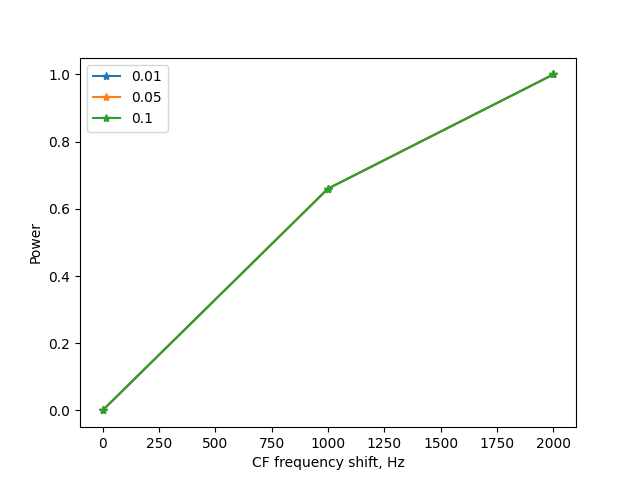

```python
plt.figure()
for each in range(3):
    plt.plot(cf_shifts, power_peakCF[each,:], '-*', label=str(alpha[each]))
plt.legend()
plt.ylabel('Power');plt.xlabel('CF frequency shift, Hz')
```

## tFM duration shifts

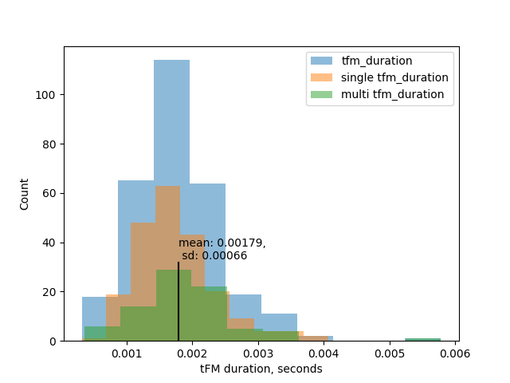

```python
make_overview_plot(df, single_bat, multi_bat, 'tfm_duration')
plt.ylabel('Count'); plt.xlabel('tFM duration, seconds')
```

### Power to pick up changes in FM durations by 12.5 and 25%

```python
results_significant = []
fm_duration_accuracy = 0.1*10**-3 # assumed duration measurement accuracy

fm_change = [1, 0.875, 0.75, 1.25, 1.125]
mean_tfm_durn = np.mean(df['tfm_duration'])
sd_tfm_durn = np.std(df['tfm_duration'])

def tfm_solitary_bat():
    solitary_bat_pf = np.random.normal(mean_tfm_durn, sd_tfm_durn, single_sample_size) # in ms
    solitary_bat_pf = include_measurement_accuracy(solitary_bat_pf, fm_duration_accuracy)
    return solitary_bat_pf

def tfm_multi_bat():
    group_bat_pf = np.random.normal(mean_tfm_durn*rel_fm_change,sd_tfm_durn, group_sample_size) # in ms
    group_bat_pf = include_measurement_accuracy(group_bat_pf, fm_duration_accuracy)
    return group_bat_pf
```

```python
tfm_all_obs_pc = []
for rel_fm_change in fm_change:
    sim_tfmdurn = get_observed_percentiles(num_trials, tfm_solitary_bat, tfm_multi_bat,
                                       num_shuffles=N_shuffles)
    tfm_all_obs_pc.append(sim_tfmdurn)
```

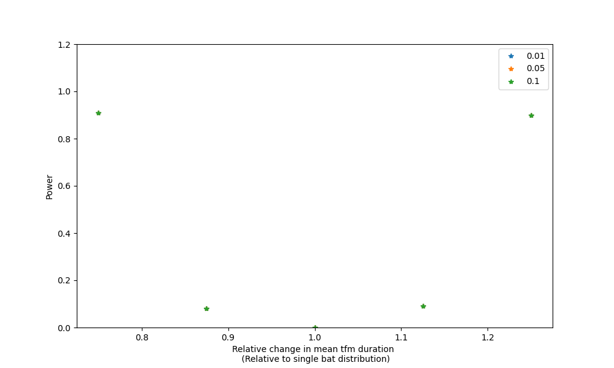

```
(0.0, 1.2)
```

```python
all_obs_pc = list(flatten(tfm_all_obs_pc))
power_tfmdurn = power_and_true_negative_at_various_alphas(alpha, len(fm_change), all_obs_pc)
plt.figure(figsize=(10,6))
for each in range(3):
    plt.plot(fm_change, power_tfmdurn[each,:], '*', label=str(alpha[each]))
plt.legend()
plt.xlabel('Relative change in mean tfm duration \n (Relative to single bat distribution)');plt.ylabel('Power')
plt.ylim(0,1.2)
```

## Picking up changes in CF rms between single and multiple bat contexts

- Fawcett et al. 2015 found a *reduction* in call source levels when *R. capensis* pairs were flown, in comparison to when the bats were flying alone. The difference in source levels was 15dB.
- Here I will check a range of effect sizes, ranging from 0 to 15dB increase in source levels. Of course, it is important to remember that we actually have *received levels* in our study. However, given the fact that the volume remains the same, a shift in source level, will lead to a shift in the received level too. Thus an increase in source level by X dB will lead to approximately the same amount of shift in received levels too.
- Here we simulate the case where multiple bats *increase* their source levels. This is because the general pattern for bats when faced with noise or conspecifics is to increase their source levels [REFS]

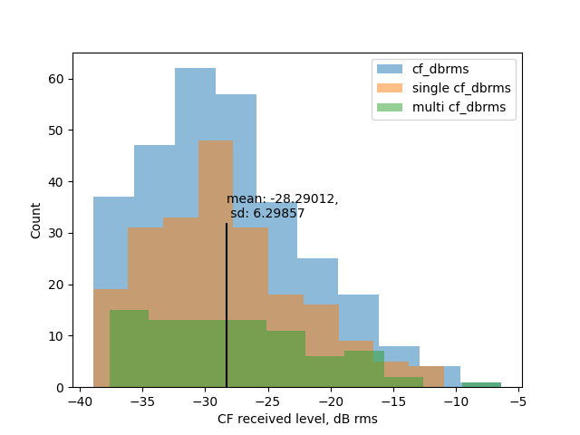

```python
make_overview_plot(df, single_bat, multi_bat, 'cf_dbrms')
plt.ylabel('Count'); plt.xlabel('CF received level, dB rms')
```

```python
single_cfrms = shuffle_overlap.generate_kde(shuffle_overlap.remove_nans(single_bat['cf_dbrms']))
multi_cfrms = shuffle_overlap.generate_kde(shuffle_overlap.remove_nans(multi_bat['cf_dbrms']))
```

```python
def single_cfrms_gen():
    return single_cfrms.resample(single_sample_size).flatten()
def multi_cfrms_gen():
    return multi_cfrms.resample(group_sample_size).flatten() + db_shift
```

```python
received_level_shift = [0, 3, 6 , 15]

cf_all_obs_pc = []
for db_shift in received_level_shift:
    sim_cfrms = get_observed_percentiles(num_trials, single_cfrms_gen, multi_cfrms_gen,
                                       num_shuffles=N_shuffles)
    cf_all_obs_pc.append(sim_cfrms)
```

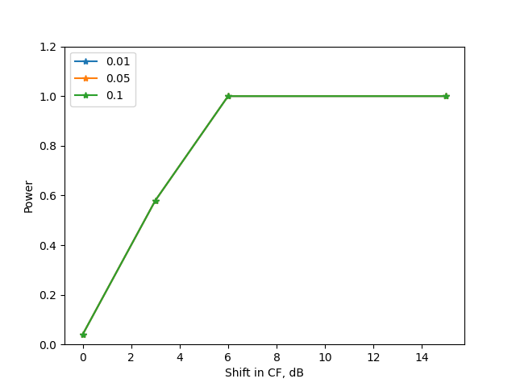

```
(0.0, 1.2)
```

```python
all_obs_pc = list(flatten(cf_all_obs_pc))
power_cfrms = power_and_true_negative_at_various_alphas(alpha, len(received_level_shift), all_obs_pc)
plt.figure()
for each in range(3):
    plt.plot(received_level_shift, power_cfrms[each,:], '-*', label=str(alpha[each]))
plt.legend()
plt.ylabel('Power');plt.xlabel('Shift in CF, dB')
plt.ylim(0,1.2)
```

## $\frac{iFM}{CF}$ ratio

The $\frac{iFM}{CF}$ and $\frac{tFM}{CF}$ ratio as reported in Tian & Schintzler 1997 [5] is used to highlight the change in intensity of the two parts. For instance, as a *R. ferrumequinum* reaches the target, the $\frac{tFM}{CF}$ dB ratio increases - which indicates that the tFM component is getting louder than the CF.

Tian & Schnitzler 1997 report ratios between ~-12 to +10. We have similar values too. Overall, in the data, there is no obvious indication of any systematic change, but we can at least see if had there been any change, would we have been able to see it?

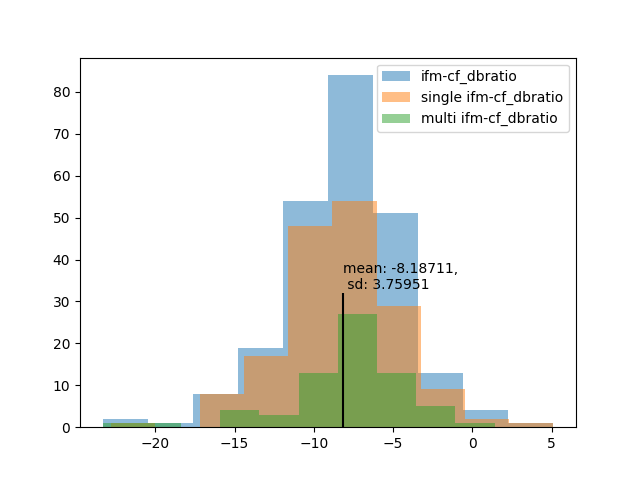

```python
colname = 'ifm-cf_dbratio'
make_overview_plot(df, single_bat, multi_bat, colname)
single_ifm_cf = shuffle_overlap.generate_kde(shuffle_overlap.remove_nans(single_bat[colname]))
multi_ifm_cf = shuffle_overlap.generate_kde(shuffle_overlap.remove_nans(multi_bat[colname]))
```

```python
def single_ifmcf_gen():
    return single_ifm_cf.resample(single_sample_size).flatten()

def multi_ifmcf_gen():
    return multi_ifm_cf.resample(group_sample_size).flatten() + ifm_increase
```

```python
fm_level_shift = [0, 1, 3, 6]
```

```python
ifm_cf_all_obs_pc = []
for ifm_increase in fm_level_shift:
    sim_ifmcfratio = get_observed_percentiles(num_trials, single_ifmcf_gen, multi_ifmcf_gen,
                                       num_shuffles=N_shuffles)
    ifm_cf_all_obs_pc.append(sim_ifmcfratio)
```

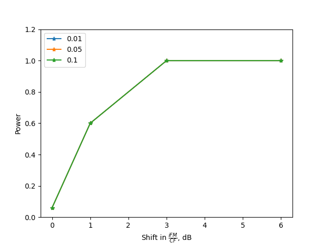

```
(0.0, 1.2)
```

```python
all_obs_pc = list(flatten(ifm_cf_all_obs_pc))
power_cfrms = power_and_true_negative_at_various_alphas(alpha, len(fm_level_shift), all_obs_pc)
plt.figure()
for each in range(3):
    plt.plot(fm_level_shift, power_cfrms[each,:], '-*', label=str(alpha[each]))
plt.legend(); plt.xlabel('Shift in $\\frac{iFM}{CF}$, dB'); plt.ylabel('Power')
plt.ylim(0,1.2)
```

## $\frac{tFM}{CF}$ ratio

Now let's do the power analysis for the tFM rather than the iFM.

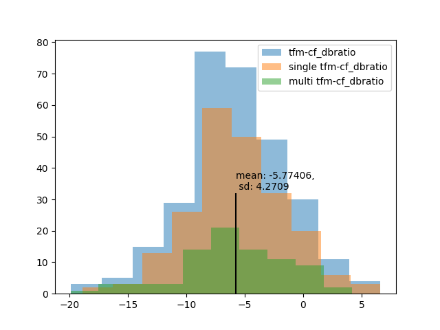

```python
colname = 'tfm-cf_dbratio'
make_overview_plot(df, single_bat, multi_bat, colname)

single_tfm_cf = shuffle_overlap.generate_kde(shuffle_overlap.remove_nans(single_bat[colname]))
multi_tfm_cf = shuffle_overlap.generate_kde(shuffle_overlap.remove_nans(multi_bat[colname]))
```

```python
def single_tfmcf_gen():
    return single_tfm_cf.resample(single_sample_size).flatten()

def multi_tfmcf_gen():
    return multi_tfm_cf.resample(group_sample_size).flatten() + tfm_increase
```

```python
tfm_cf_all_obs_pc = []
for tfm_increase in fm_level_shift:
    sim_tfmcfratio = get_observed_percentiles(num_trials, single_tfmcf_gen, multi_tfmcf_gen,
                                       num_shuffles=N_shuffles)
    tfm_cf_all_obs_pc.append(sim_ifmcfratio)
```

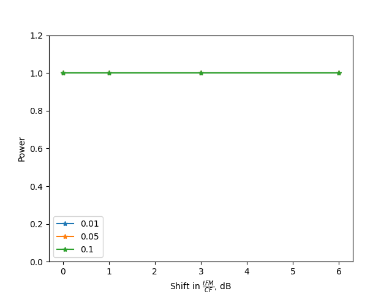

```
(0.0, 1.2)
```

```python
all_obs_pc = list(flatten(tfm_cf_all_obs_pc))
power_cfrms = power_and_true_negative_at_various_alphas(alpha, len(fm_level_shift), all_obs_pc)
plt.figure()
for each in range(3):
    plt.plot(fm_level_shift, power_cfrms[each,:], '-*', label=str(alpha[each]))
plt.legend(); plt.xlabel('Shift in $\\frac{tFM}{CF}$, dB'); plt.ylabel('Power')
plt.ylim(0,1.2)
```

## tfm_peak_amplitude

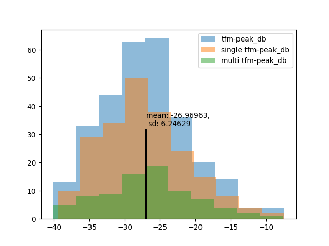

```python
colname = 'tfm-peak_db'
make_overview_plot(df, single_bat, multi_bat, colname)
single_tfm_peak = shuffle_overlap.generate_kde(shuffle_overlap.remove_nans(single_bat[colname]))
multi_tfm_peak = shuffle_overlap.generate_kde(shuffle_overlap.remove_nans(multi_bat[colname]))
```

```python
peak_dB_shift = [0, 3, 6, 15]
```

```python
def single_tfmpeakdb_gen():
    return single_tfm_peak.resample(single_sample_size).flatten()

def multi_tfmpeakdb_gen():
    return multi_tfm_peak.resample(group_sample_size).flatten() + tfm_peak_shift
```

```python
tfm_peakdB = []
for tfm_peak_shift in peak_dB_shift:
    sim_tfmpeakdb = get_observed_percentiles(num_trials, single_tfmpeakdb_gen, multi_tfmpeakdb_gen,
                                       num_shuffles=N_shuffles)
    tfm_peakdB.append(sim_tfmpeakdb)
```

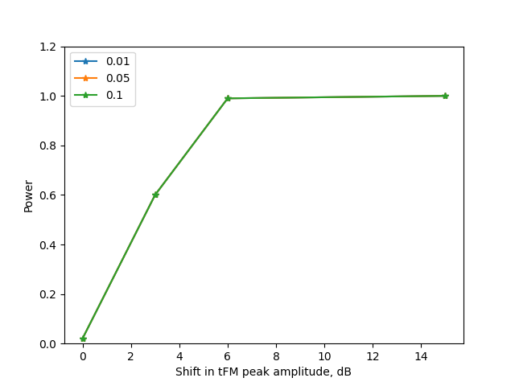

```
(0.0, 1.2)
```

```python
all_obs_pc = list(flatten(tfm_peakdB))
power_cfrms = power_and_true_negative_at_various_alphas(alpha, len(peak_dB_shift), all_obs_pc)
plt.figure()
for each in range(3):
    plt.plot(peak_dB_shift, power_cfrms[each,:], '-*', label=str(alpha[each]))
plt.legend(); plt.xlabel('Shift in tFM peak amplitude, dB'); plt.ylabel('Power')
plt.ylim(0,1.2)
```

## ifm_peak_amplitude

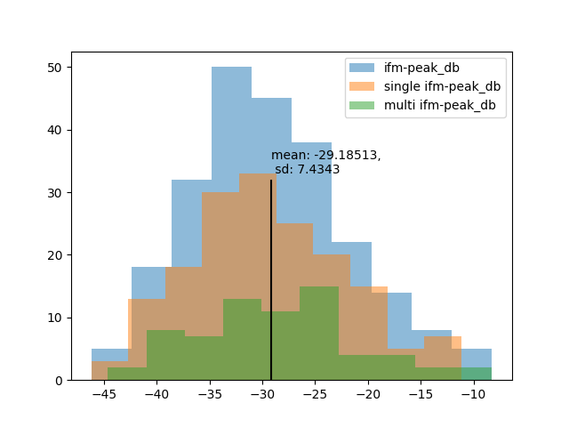

```python
colname = 'ifm-peak_db'
make_overview_plot(df, single_bat, multi_bat, colname)
single_ifm_peak = shuffle_overlap.generate_kde(shuffle_overlap.remove_nans(single_bat[colname]))
multi_ifm_peak = shuffle_overlap.generate_kde(shuffle_overlap.remove_nans(multi_bat[colname]))
```

```python
def single_ifmpeakdb_gen():
    return single_ifm_peak.resample(single_sample_size).flatten()

def multi_ifmpeakdb_gen():
    return multi_ifm_peak.resample(group_sample_size).flatten() + ifm_peak_shift
```

```python
ifm_peakdB = []
for ifm_peak_shift in peak_dB_shift:
    sim_ifmpeakdb = get_observed_percentiles(num_trials, single_ifmpeakdb_gen, multi_ifmpeakdb_gen,
                                       num_shuffles=N_shuffles)
    ifm_peakdB.append(sim_ifmpeakdb)
```

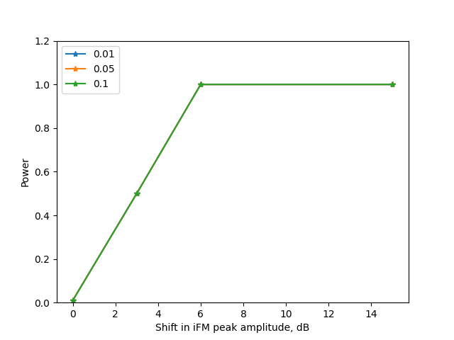

```
(0.0, 1.2)
```

```python
all_obs_pc = list(flatten(ifm_peakdB))
power_cfrms = power_and_true_negative_at_various_alphas(alpha, len(peak_dB_shift), all_obs_pc)
plt.figure()
for each in range(3):
    plt.plot(peak_dB_shift, power_cfrms[each,:], '-*', label=str(alpha[each]))
plt.legend(); plt.xlabel('Shift in iFM peak amplitude, dB'); plt.ylabel('Power')
plt.ylim(0,1.2)
```

## ifm_duration

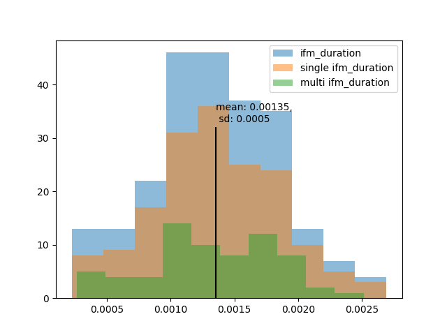

```python
colname = 'ifm_duration'
make_overview_plot(df, single_bat, multi_bat, colname)

mean_ifm_durn = np.mean(df['ifm_duration'])
sd_ifm_durn = np.std(df['ifm_duration'])

def ifm_solitary_bat():
    solitary_bat_pf = np.random.normal(mean_ifm_durn, sd_ifm_durn, single_sample_size) # in ms
    solitary_bat_pf = include_measurement_accuracy(solitary_bat_pf, fm_duration_accuracy)
    return solitary_bat_pf

def ifm_multi_bat():
    group_bat_pf = np.random.normal(mean_ifm_durn*rel_fm_change,sd_ifm_durn, group_sample_size) # in ms
    group_bat_pf = include_measurement_accuracy(group_bat_pf, fm_duration_accuracy)
    return group_bat_pf
```

```python
ifm_duration = []
for rel_fm_change in fm_change:
    sim_ifmpeakdb = get_observed_percentiles(num_trials, ifm_solitary_bat, ifm_multi_bat,
                                       num_shuffles=N_shuffles)
    ifm_duration.append(sim_ifmpeakdb)
```

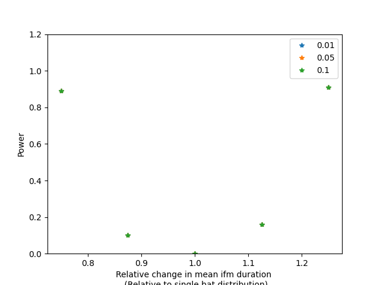

```
(0.0, 1.2)
```

```python
all_obs_pc = list(flatten(ifm_duration))
power_cfrms = power_and_true_negative_at_various_alphas(alpha, len(fm_change), all_obs_pc)
plt.figure()
for each in range(3):
    plt.plot(fm_change, power_cfrms[each,:], '*', label=str(alpha[each]))
plt.legend();
plt.xlabel('Relative change in mean ifm duration \n (Relative to single bat distribution)');plt.ylabel('Power')
plt.ylim(0,1.2)
```

## cf_duration

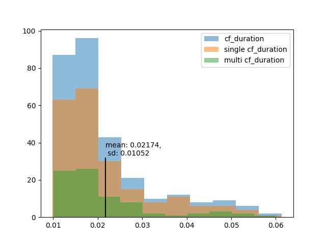

```python
colname = 'cf_duration'
make_overview_plot(df, single_bat, multi_bat, colname)

mean_cf_durn = np.mean(df[colname])
sd_cf_durn = np.std(df[colname])

def cfdurn_solitary_bat():
    solitary_bat_pf = np.random.normal(mean_cf_durn, sd_cf_durn, single_sample_size) # in ms
    solitary_bat_pf = include_measurement_accuracy(solitary_bat_pf, fm_duration_accuracy)
    return solitary_bat_pf

def cfdurn_multi_bat():
    group_bat_pf = np.random.normal(mean_cf_durn*rel_change,sd_cf_durn, group_sample_size) # in ms
    group_bat_pf = include_measurement_accuracy(group_bat_pf, fm_duration_accuracy)
    return group_bat_pf
```

```python
cfdurn_all_obs_pc = []
for rel_change in fm_change:
    sim_cfdurn = get_observed_percentiles(num_trials, cfdurn_solitary_bat, cfdurn_multi_bat,
                                       num_shuffles=N_shuffles)
    cfdurn_all_obs_pc.append(sim_cfdurn)
```

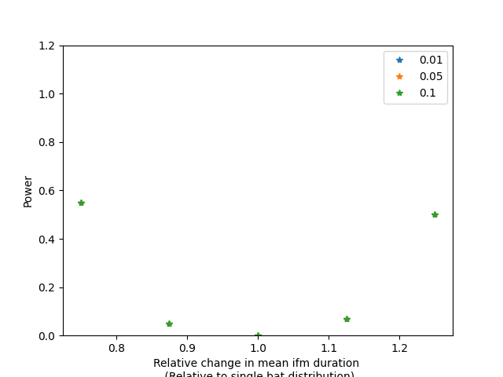

```
(0.0, 1.2)
```

```python
all_obs_pc = list(flatten(cfdurn_all_obs_pc))
power_cfrms = power_and_true_negative_at_various_alphas(alpha, len(fm_change), all_obs_pc)
plt.figure()
for each in range(3):
    plt.plot(fm_change, power_cfrms[each,:], '*', label=str(alpha[each]))
plt.legend();
plt.xlabel('Relative change in mean ifm duration \n (Relative to single bat distribution)');plt.ylabel('Power')
plt.ylim(0,1.2)
```

## tfm terminal frequency

Fawcett et al. 2015 found at drop of between 3-5 kHz in the -10 dB frequency in the *i* and *t* FM parts of the calls.

```python
minus10_shift = np.array([0, 3, 5])*10**3
```

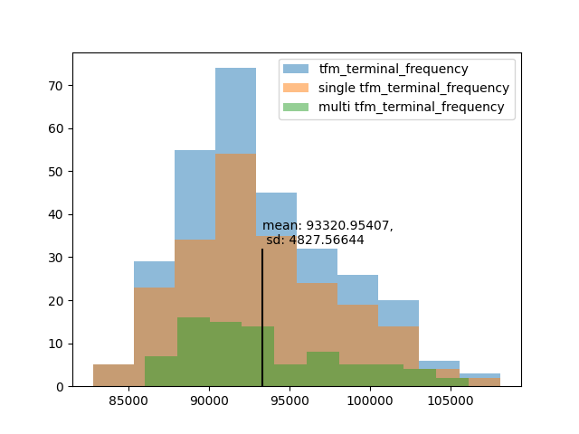

```python
colname = 'tfm_terminal_frequency'
make_overview_plot(df, single_bat, multi_bat, colname)
single_tfm_tf = shuffle_overlap.generate_kde(shuffle_overlap.remove_nans(single_bat[colname]))
multi_tfm_tf = shuffle_overlap.generate_kde(shuffle_overlap.remove_nans(multi_bat[colname]))

def single_tfm10dB_gen():
    return single_tfm_tf.resample(single_sample_size).flatten()

def multi_tfm10dB_gen():
    return multi_tfm_tf.resample(group_sample_size).flatten() + tf_shift
```

```python
tfm_tf = []
for tf_shift in minus10_shift:
    sim_tfm_tf = get_observed_percentiles(num_trials, single_tfm10dB_gen, multi_tfm10dB_gen,
                                       num_shuffles=N_shuffles)
    tfm_tf.append(sim_tfm_tf)
```

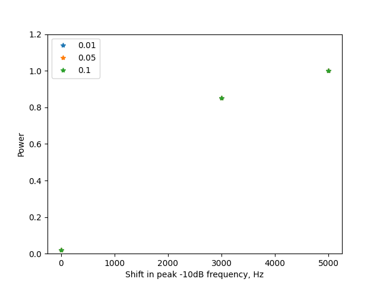

```
(0.0, 1.2)
```

```python
all_obs_pc = list(flatten(tfm_tf))
power_cfrms = power_and_true_negative_at_various_alphas(alpha, len(minus10_shift), all_obs_pc)
plt.figure()
for each in range(3):
    plt.plot(minus10_shift, power_cfrms[each,:], '*', label=str(alpha[each]))
plt.legend();
plt.xlabel('Shift in peak -10dB frequency, Hz');plt.ylabel('Power')
plt.ylim(0,1.2)
```

## ifm_terminal_frequency

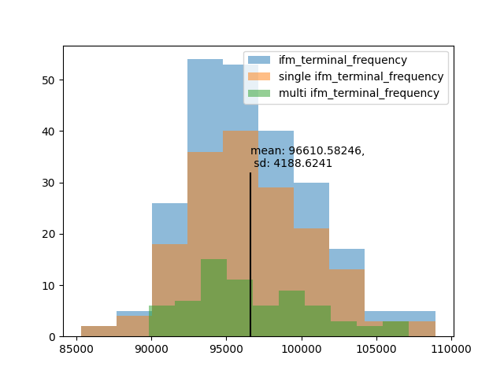

```python
colname = 'ifm_terminal_frequency'
make_overview_plot(df, single_bat, multi_bat, colname)
single_ifm_tf = shuffle_overlap.generate_kde(shuffle_overlap.remove_nans(single_bat[colname]))
multi_ifm_tf = shuffle_overlap.generate_kde(shuffle_overlap.remove_nans(multi_bat[colname]))

def single_ifm10dB_gen():
    return single_ifm_tf.resample(single_sample_size).flatten()

def multi_ifm10dB_gen():
    return multi_ifm_tf.resample(group_sample_size).flatten() + tf_shift
```

```python
ifm_tf = []
for tf_shift in minus10_shift:
    sim_ifm_tf = get_observed_percentiles(num_trials, single_ifm10dB_gen, multi_ifm10dB_gen,
                                       num_shuffles=N_shuffles)
    ifm_tf.append(sim_ifm_tf)
```

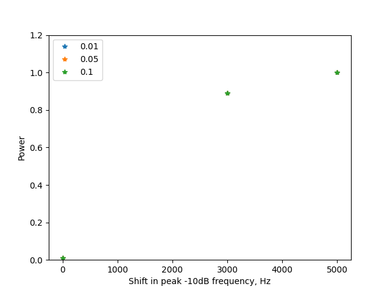

```
(0.0, 1.2)
```

```python
all_obs_pc = list(flatten(ifm_tf))
power_cfrms = power_and_true_negative_at_various_alphas(alpha, len(minus10_shift), all_obs_pc)
plt.figure()
for each in range(3):
    plt.plot(minus10_shift, power_cfrms[each,:], '*', label=str(alpha[each]))
plt.legend();
plt.xlabel('Shift in peak -10dB frequency, Hz');plt.ylabel('Power')
plt.ylim(0,1.2)
```

## References

1. Lakens, Daniel, Observed power, and what to do if your editor asks for post-hoc power analyses, blog-post. Accessed from http://daniellakens.blogspot.com/2014/12/observed-power-and-what-to-do-if-your.html on 19-06-2020
2. Zhang Y, Hedo R, Rivera A, et al, Post hoc power analysis: is it an informative and meaningful analysis? General Psychiatry 2019;32:e100069. doi: 10.1136/gpsych-2019-100069
3. Fawcett, K., Jacobs, D. S., Surlykke, A., & Ratcliffe, J. M. (2015). Echolocation in the bat, Rhinolophus capensis: the influence of clutter, conspecifics and prey on call design and intensity. Biology Open, 4(6), 693-701.
4. di Stephano, J. (2003). How much power is enough? Against the development of an arbitrary convention for statistical power calculations. Functional Ecology, 17(5), 707-709.
5. Tian, B., & Schnitzler, H. U. (1997). Echolocation signals of the greater horseshoe bat (Rhinolophus ferrumequinum) in transfer flight and during landing. The Journal of the Acoustical Society of America, 101(4), 2347-2364.

```python
import datetime as dt
dt.datetime.now()
```

```
datetime.datetime(2020, 7, 8, 1, 44, 1, 579092)
```